# Week 06: R for Data Analytics (Data Screening Part 1)

### Fixing Issues

How do we fix these? 1. Find the original data and figure out what the point should be. 2. **Delete that data point** (set to `NA`) but not the entire participant.

**Example: Using Logical Subsetting** Suppose `Grade` cannot be > 12 and `Absences` cannot be > 15.

```r
# Check Grade
summary(notypos$Grade)
```

```
##    Min. 1st Qu.  Median    Mean 3rd Qu.    Max.
##   1.000   4.000   6.000   5.883   8.000  35.000
```

```r
# Code Explanation: "In the Grade column, find values > 12, and set them to NA"
notypos$Grade[ notypos$Grade > 12 ] <- NA
summary(notypos$Grade)
```

```
##    Min. 1st Qu.  Median    Mean 3rd Qu.    Max.    NA's
##   1.000   4.000   6.000   5.669   8.000  11.000       1
```

```r
# Check Absences
summary(notypos$Absences)
```

```
##    Min. 1st Qu.  Median    Mean 3rd Qu.    Max.
##   1.000   2.000   2.000   3.358   5.000  35.000
```

```r
notypos$Absences[ notypos$Absences > 15 ] <- NA
summary(notypos$Absences)
```

```
##    Min. 1st Qu.  Median    Mean 3rd Qu.    Max.    NA's
##   1.000   2.000   2.000   3.125   5.000   7.000       1
```

**Example: Multiple Columns** If multiple columns (e.g., RS items) have the same range (1-7), we can clean them all at once.

```r
# Assuming RS columns are from column 5 onwards (adjust indices as needed)
# In our simulated data, RS columns are 5, 6, 7
rs_cols <- grep("RS", names(notypos))

# Check before
summary(notypos[ , rs_cols])
```

```
##       RS1             RS2             RS3             RS4            RS5
##  Min.   :1.000   Min.   :1.000   Min.   : 1.00   Min.   :1.00   Min.   :1.000
##  1st Qu.:4.000   1st Qu.:4.000   1st Qu.: 3.00   1st Qu.:3.00   1st Qu.:3.000
##  Median :5.000   Median :5.000   Median : 4.00   Median :5.00   Median :4.000
##  Mean   :4.858   Mean   :4.962   Mean   : 4.42   Mean   :4.55   Mean   :4.448
##  3rd Qu.:6.000   3rd Qu.:6.000   3rd Qu.: 6.00   3rd Qu.:7.00   3rd Qu.:6.750
##  Max.   :7.000   Max.   :7.000   Max.   :18.00   Max.   :7.00   Max.   :7.000
##  NA's   :3       NA's   :5       NA's   :6       NA's   :6      NA's   :3
##       RS6         RS7              RS8             RS9             RS10
##  Min.   :1   Min.   : 1.000   Min.   :1.000   Min.   :1.000   Min.   :1.000
##  1st Qu.:4   1st Qu.: 4.000   1st Qu.:3.000   1st Qu.:4.000   1st Qu.:4.000
##  Median :5   Median : 5.000   Median :5.000   Median :5.000   Median :5.500
##  Mean   :5   Mean   : 5.082   Mean   :4.764   Mean   :4.692   Mean   :5.313
##  3rd Qu.:7   3rd Qu.: 7.000   3rd Qu.:7.000   3rd Qu.:6.000   3rd Qu.:7.000
##  Max.   :7   Max.   :10.000   Max.   :7.000   Max.   :7.000   Max.   :7.000
##  NA's   :7   NA's   :3        NA's   :10      NA's   :7       NA's   :3
##       RS11            RS12            RS13             RS14
##  Min.   :1.000   Min.   :1.000   Min.   : 1.000   Min.   :1.00
##  1st Qu.:3.000   1st Qu.:5.000   1st Qu.: 4.000   1st Qu.:4.00
##  Median :5.000   Median :6.000   Median : 6.000   Median :5.00
##  Mean   :4.641   Mean   :5.552   Mean   : 5.507   Mean   :4.97
##  3rd Qu.:6.500   3rd Qu.:7.000   3rd Qu.: 7.000   3rd Qu.:7.00
##  Max.   :7.000   Max.   :7.000   Max.   :15.000   Max.   :7.00
##  NA's   :6       NA's   :3       NA's   :3        NA's   :5
```

```r
# Apply fix: any value > 7 in these columns becomes NA
notypos[ , rs_cols][ notypos[ , rs_cols] > 7 ] <- NA

# Check after
summary(notypos[ , rs_cols])
```

```
##       RS1             RS2             RS3             RS4            RS5
##  Min.   :1.000   Min.   :1.000   Min.   :1.000   Min.   :1.00   Min.   :1.000
##  1st Qu.:4.000   1st Qu.:4.000   1st Qu.:3.000   1st Qu.:3.00   1st Qu.:3.000
##  Median :5.000   Median :5.000   Median :4.000   Median :5.00   Median :4.000
##  Mean   :4.858   Mean   :4.962   Mean   :4.315   Mean   :4.55   Mean   :4.448
##  3rd Qu.:6.000   3rd Qu.:6.000   3rd Qu.:6.000   3rd Qu.:7.00   3rd Qu.:6.750
##  Max.   :7.000   Max.   :7.000   Max.   :7.000   Max.   :7.00   Max.   :7.000
##  NA's   :3       NA's   :5       NA's   :7       NA's   :6      NA's   :3
##       RS6         RS7             RS8             RS9             RS10
##  Min.   :1   Min.   :1.000   Min.   :1.000   Min.   :1.000   Min.   :1.000
##  1st Qu.:4   1st Qu.:4.000   1st Qu.:3.000   1st Qu.:4.000   1st Qu.:4.000
##  Median :5   Median :5.000   Median :5.000   Median :5.000   Median :5.500
##  Mean   :5   Mean   :5.008   Mean   :4.764   Mean   :4.692   Mean   :5.313
##  3rd Qu.:7   3rd Qu.:7.000   3rd Qu.:7.000   3rd Qu.:6.000   3rd Qu.:7.000
##  Max.   :7   Max.   :7.000   Max.   :7.000   Max.   :7.000   Max.   :7.000
##  NA's   :7   NA's   :5       NA's   :10      NA's   :7       NA's   :3
##       RS11            RS12            RS13            RS14
##  Min.   :1.000   Min.   :1.000   Min.   :1.000   Min.   :1.00
##  1st Qu.:3.000   1st Qu.:5.000   1st Qu.:4.000   1st Qu.:4.00
##  Median :5.000   Median :6.000   Median :6.000   Median :5.00
##  Mean   :4.641   Mean   :5.552   Mean   :5.364   Mean   :4.97
##  3rd Qu.:6.500   3rd Qu.:7.000   3rd Qu.:7.000   3rd Qu.:7.00
##  Max.   :7.000   Max.   :7.000   Max.   :7.000   Max.   :7.00
##  NA's   :6       NA's   :3       NA's   :5       NA's   :5
```

# Part 3: Missing Data

Use `summary()` or `apply()` to count `NA` values.

```r
apply(notypos, 2, function(x) { sum(is.na(x)) })
```

```
##      Sex      Age      SES    Grade Absences      RS1      RS2      RS3
##        1        5        0        1        1        3        5        7
##      RS4      RS5      RS6      RS7      RS8      RS9     RS10     RS11
##        6        3        7        5       10        7        3        6
##     RS12     RS13     RS14   Health
##        3        5        5        0
```

## 3.1 Diagnosing Missingness

Understanding *why* data is missing is crucial [1]:

1. **MCAR (Missing Completely at Random):**
   - **Analogy:** You are carrying a tray of blood samples and trip, breaking random vials. The missingness has nothing to do with the patient’s health.
   - **Handling:** Safe to replace or ignore.
2. **MNAR (Missing Not at Random):**
   - **Analogy:** Patients with very high blood pressure refuse to have it measured because they are scared. The missingness *is* related to the health outcome.
   - **Handling:** **Dangerous** to replace. Excluding might be safer.

> **Quick Fix:** For simple statistics, you can often use `na.rm = TRUE` (e.g., `mean(x, na.rm = TRUE)`) to ignore missing values without permanently deleting them [1].

## 3.2 Visualizing Missing Data

The `VIM` package helps visualize patterns.

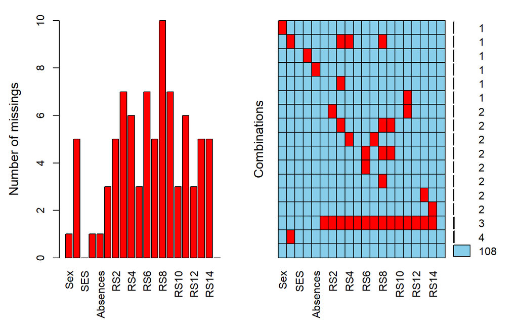

```r
aggr(notypos, numbers = TRUE, prop = FALSE)
```

## 3.3 Handling Missing Data

### By Rows (Participants)

Check the percentage of missing data per participant.

```r
# Create a custom function to calculate % missing
percentmiss <- function(x){ sum(is.na(x))/length(x) * 100 }

# Apply it to rows (margin = 1)
missing <- apply(notypos, 1, percentmiss)
table(missing)
```

```
## missing
##   0   5  10  15  20  70
## 108  17   4   4   1   3
```

We can create subsets: - **Replaceable:** Participants with $\le 5\%$ missing data. - **Not Replaceable:** Participants with $> 5\%$ missing data (often excluded or analyzed separately).

```r
replace_rows <- subset(notypos, missing <= 5)
noreplace_rows <- subset(notypos, missing > 5)

cat("Original N:", nrow(notypos), "\n")
```

```
## Original N: 137
```

```r
cat("Rows to replace:", nrow(replace_rows), "\n")
```

```
## Rows to replace: 125
```

```r
cat("Rows dropped/kept separate:", nrow(noreplace_rows), "\n")
```

```
## Rows dropped/kept separate: 12
```

### Multiple Imputation with `mice`

We do not replace missing data for categorical/demographic variables (Sex, SES, Grade). We use them to help estimate missing values in other variables.

**What is MICE?** *Multivariate Imputation by Chained Equations*. It creates multiple “complete” datasets by guessing missing values based on relationships with other variables. It’s better than just plugging in the mean because it preserves the variance in the data.

```r
# Run mice on our replaceable rows
# printFlag = FALSE keeps the output clean
temp_no_miss <- mice(replace_rows, printFlag = FALSE, seed = 123)
```

Now, complete the dataset (pick one of the imputations, e.g., #1).

```r
nomiss <- complete(temp_no_miss, 1)
all_columns <- nomiss # This is our clean dataset
```

### Visual Verification: Did Imputation Change Data Shape?

It is critical to verify that imputing data didn’t distort our variables. The distribution should look roughly the same before and after.

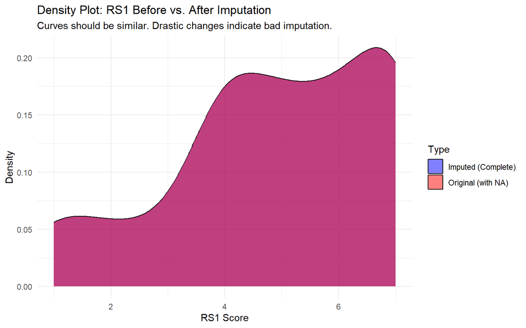

```r
# Combine data for plotting
before <- data.frame(Value = replace_rows$RS1, Type = "Original (with NA)")
after <- data.frame(Value = all_columns$RS1, Type = "Imputed (Complete)")
comparison <- rbind(before, after)

ggplot(comparison, aes(x = Value, fill = Type)) +
  geom_density(alpha = 0.5) +
  labs(title = "Density Plot: RS1 Before vs. After Imputation",
       subtitle = "Curves should be similar. Drastic changes indicate bad imputation.",
       x = "RS1 Score",
       y = "Density") +
  theme_minimal() +
  scale_fill_manual(values = c("blue", "red"))
```

**Interpretation:** If the Red and Blue curves overlap significantly, your imputation is good! It means you filled in the holes without changing the “story” of the data.

# Part 4: Outliers

**Definition:** A case with an extreme value on one or multiple variables. **Why remove them?** The mean is sensitive to outliers. We use a strict criterion ($p < .001$) to remove only very extreme scores.

## 4.1 Univariate Outliers (Z-scores)

For a single variable, we can use **Z-scores**. - **Concept:** A Z-score tells you how many standard deviations a score is from the mean. - $Z = 0$: Exactly average. - $Z = +1$: One standard deviation above average. - $Z = +3.29$: Extremely high (less than 0.1% chance). - **Criterion:** $Z > 3.29$ or $Z < -3.29$ (corresponding to $p < .001$) [1].

```r
# Calculate Z-scores for RS1 (as an example)
# scale() function calculates Z-scores
all_columns$RS1_z <- scale(all_columns$RS1)

# Check for outliers
summary(all_columns$RS1_z)
```

```
##        V1
##  Min.   :-2.15130
##  1st Qu.:-0.50153
##  Median : 0.04839
##  Mean   : 0.00000
##  3rd Qu.: 1.14824
##  Max.   : 1.14824
```

### Visualizing Z-scores

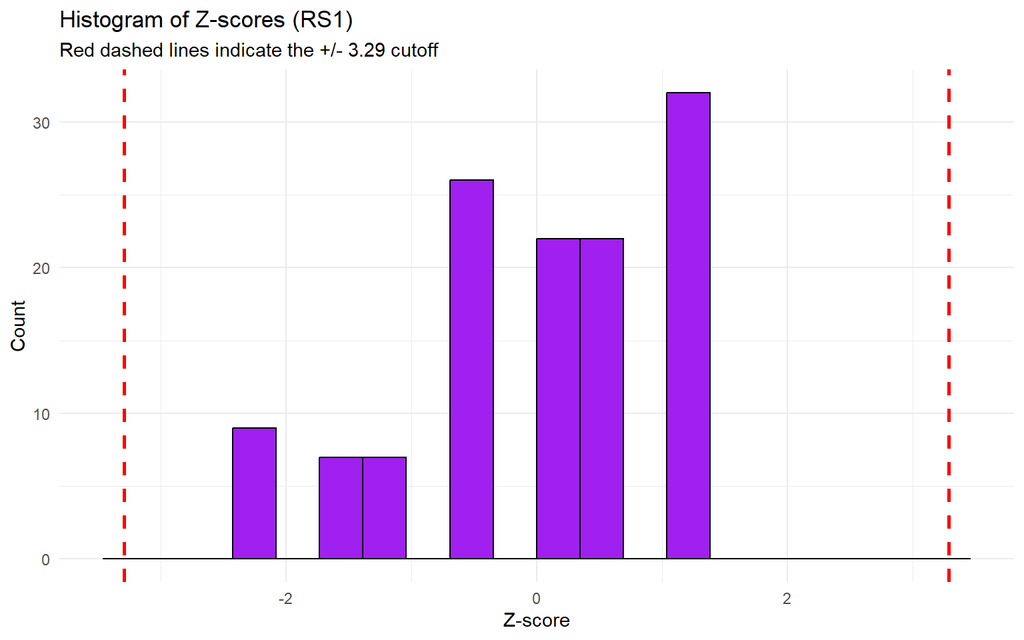

```r
ggplot(all_columns, aes(x = RS1_z)) +
  geom_histogram(bins = 20, fill = "purple", color = "black") +
  geom_vline(xintercept = c(-3.29, 3.29), linetype = "dashed", color = "red", size = 1) +
  labs(title = "Histogram of Z-scores (RS1)",
       subtitle = "Red dashed lines indicate the +/- 3.29 cutoff",
       x = "Z-score",
       y = "Count") +
  theme_minimal()
```

**Interpretation:** Any bars *outside* the red dashed lines represent outliers that should be removed or investigated.